# unemployment data analysis

### Unemployment Data Analysis

#### The box plot of all the individual countries for the 5 year duration

[interactive chart not shown]

We can better understand the data if we use a box plot and scatter plot together. There is a clear trend in the data over time, with a mean of 18.285 percent from 2010 to 2014 and a range of 18.2546 percent. statistical plots such as box plots, scatter plots, etc. of data from certain countries and getting a fast look at how different countries compare against one another in terms of statistical analysis.

#### Comparison of the countries having unemployment rate

[interactive chart not shown]

Several nations, such as South Africa and Bosnia and Herzegovina, which were already experiencing high unemployment rates in 2010 are still among the countries with the highest jobless rates in 2014. The situation in several European nations, on the other hand, has worsened with time.

#### Countries wise Best & Worst Performers

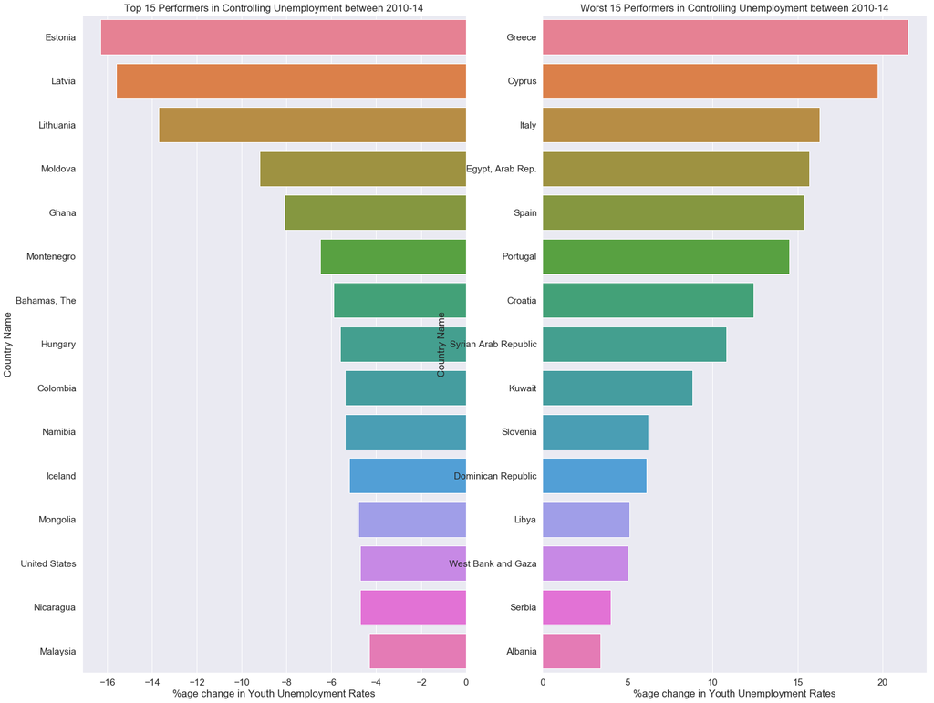

#### unemployment growth around globe in 5 years

[interactive chart not shown]

Most nations studied had either a minor positive increase or a net drop in unemployment rates over the five-year period from 2010 to 2014. The remainder of the globe seems to be doing quite well, other from few North African and Southern European countries that have suffered a significant rise in unemployment. Just 0.19 percent, 1.5 percent, and 1.7 percent growth in India, China, and Australia over the last five years shows that the South Asian and Oceania area is performing well.

#### Non Country Data Analysis

[interactive chart not shown]

As can be seen from the graphs above, Asian countries (East Asia & Pacific, South Asia & Latin America) have lower unemployment rates than the global average. This serves as a basis for comparison. Economic crisis that has been particularly painful for countries in the European Union and the Middle East appears to be strengthening the argument that emerging countries are propelling the global economy ahead rather than their wealthier counterparts.

[interactive chart not shown]

Based on the nation's income levels, the world's unemployment rates are compared to those in each country. While less developed and emerging nations are able to provide more job chances and limit unemployment rates from growing, high-income countries suffer from greater unemployment rates. This is evident from the scatter plot.